# Exploring Baby Names

Auren Ferguson

27 December 2016

# 1 Introduction

This document explores US baby naming trends from 1910-2015. The data can be downloaded from http://www.ssa.gov/oact/babynames/state/namesbystate.zip

# 2 Exploring Baby Names

## 2.1 Loading librarys

```r
library(data.table)
library(dplyr)
library(ggplot2)
library(scales)
```

## 2.2 Reading Data In and Aggregating

The data comes in the format of names by year for each state. In order to get a national figure we have to read in the data from each and bind them together.

```r
# filelist = list.files(path = "/Users/aurenferguson/Downloads/namesbystate", pattern = ".TXT")
#
# datalist = lapply(filelist, function(x)read.csv(x, header=F))
#
# #assuming the same header/columns for all files
# baby_names = bind_rows(datalist)
#
# # converting to tbl
# baby_names <- as.tbl(baby_names)
#
# # renaming columns
# baby_names <- dplyr::rename(.data = baby_names, state = V1, sex = V2, year = V3, name = V4, amount = V5)
#
# fwrite(baby_names, file = "baby_names_all_states.csv")
```

The code is commented out as I have already done this and exported a national csv file which is read in.

```r
baby_names <- as.tbl(fread(input = "baby_names_all_states.csv"))
```

```
##
Read 93.2% of 5743017 rows
Read 5743017 rows and 5 (of 5) columns from 0.105 GB file in 00:00:03
```

```r
head(baby_names)
```

```
## # A tibble: 6 × 5
##   state   sex  year     name amount
##   <chr> <chr> <int>    <chr>  <int>
## 1    AK     F  1910     Mary     14
## 2    AK     F  1910    Annie     12
## 3    AK     F  1910     Anna     10
## 4    AK     F  1910 Margaret      8
## 5    AK     F  1910    Helen      7
## 6    AK     F  1910    Elsie      6
```

## 2.3 Most Popular Baby Names of All Time

Its interesting to see which are the most popular names of all time (1910-2015 anyway)

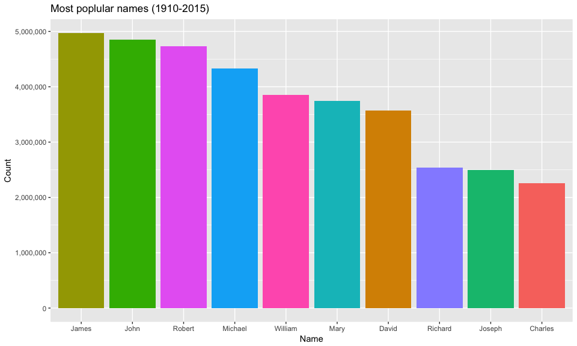

```r
popular_names_all_time <- function(df){
  df <- df %>% group_by(name) %>% summarise(total = sum(amount)) %>%
    arrange(desc(total)) %>% head(10)
  ggplot(data = df, aes(x = reorder(name, -total), y = total, fill = name)) +
    geom_bar(stat = "identity") +
    scale_y_continuous(labels = comma) +
    guides(fill = FALSE) +
    ylab("Count") +
    xlab("Name") +
    labs(title = "Most poplular names (1910-2015)")
}

popular_names_all_time(baby_names)
```

## 2.4 Gender Ambigious Names

Will try and find the most gender ambiguous names of the whole data set and then on specific years. However, there are many ways to tackle this problem that will get different results. I will use two methods: finding common gender ambiguous names where there are similar amounts of male and females with same name and a method that gets the exact same amount of males and females for a specific year. This method however generally picks out unusual names with low counts.

### 2.4.1 Common Ambigious Names

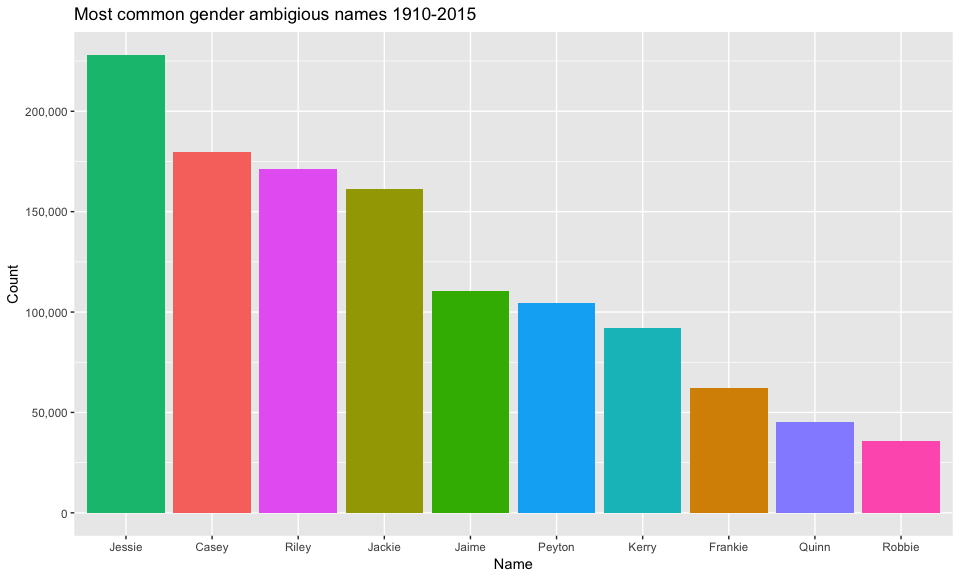

```r
Gender_ambig_common_name <- function(df, yr = NULL){
  if(missing(yr)){

    # only taking common names i.e, total > 100
    df <- df %>% group_by(name, sex) %>%
      summarise(total = sum(amount)) %>% arrange(desc(total)) %>% filter(total >= 100)

    # Keeps all duplicates, i.e. male and female of same name
    df <- df[duplicated(df$name) | duplicated(df$name, fromLast=TRUE), ]

    # Another dataframe that goes to name level,
    #therefore the difference between total is due to amount of male and female
    df_a <- df %>% group_by(name) %>% summarise(total_amt = sum(total)) %>%
      arrange(desc(total_amt)) %>% rename(total_male_female = total_amt)

    # Joins the 2 dataframes, allowing a ratio of male female to be calculated
    df <- left_join(df, df_a, by = "name")

    # Male/Female calculation ratio of total for each name
    df$ratio <- df$total / df$total_male_female

    # selects ratio of 0.5 and removes duplicates for clarity.
    # 0.5 corresponds to a name being exactly half male and half female
    df <- df %>% filter(ratio >= 0.4 & ratio <= 0.6) %>% distinct(name,.keep_all = T) %>%
      arrange(desc(total_male_female)) %>% head(10)

    # Visualising results
    ggplot(data = df, aes(x = reorder(name, -total_male_female), y = total_male_female, fill = name)) +
      geom_bar(stat = "identity") +
      scale_y_continuous(labels = comma) +
      guides(fill = FALSE) +
      ylab("Count") +
      xlab("Name") +
      ggtitle(label = paste("Most common gender ambigious names 1910-2015"))

  }else{
    # only taking common names i.e, total > 100
    df <- df %>% filter(year == yr) %>% group_by(name, sex) %>%
      summarise(total = sum(amount)) %>% arrange(desc(total)) %>% filter(total >= 100)

    # Keeps all duplicates, i.e. male and female of same name
    df <- df[duplicated(df$name) | duplicated(df$name, fromLast=TRUE), ]

    # Another dataframe that goes to name level,
    #therefore the difference between total is due to amount of male and female
    df_a <- df %>% group_by(name) %>% summarise(total_amt = sum(total)) %>%
      arrange(desc(total_amt)) %>% rename(total_male_female = total_amt)

    # Joins the 2 dataframes, allowing a ratio of male female to be calculated
    df <- left_join(df, df_a, by = "name")

    # Male/Female calculation ratio of total for each name
    df$ratio <- df$total / df$total_male_female

    # selects ratio of 0.5 and removes duplicates for clarity.
    # 0.5 corresponds to a name being exactly half male and half female
    df <- df %>% filter(ratio >= 0.4 & ratio <= 0.6) %>% distinct(name,.keep_all = T) %>%
      arrange(desc(total_male_female)) %>% head(10)

    # Visualising results
    ggplot(data = df, aes(x = reorder(name, -total_male_female), y = total_male_female, fill = name)) +
      geom_bar(stat = "identity") +
      scale_y_continuous(labels = comma) +
      guides(fill = FALSE) +
      ylab("Count") +
      xlab("Name") +
      ggtitle(label = paste("Most common gender ambigious names", yr))
  }
}

# Most ambigious names of all
Gender_ambig_common_name(df = baby_names)
```

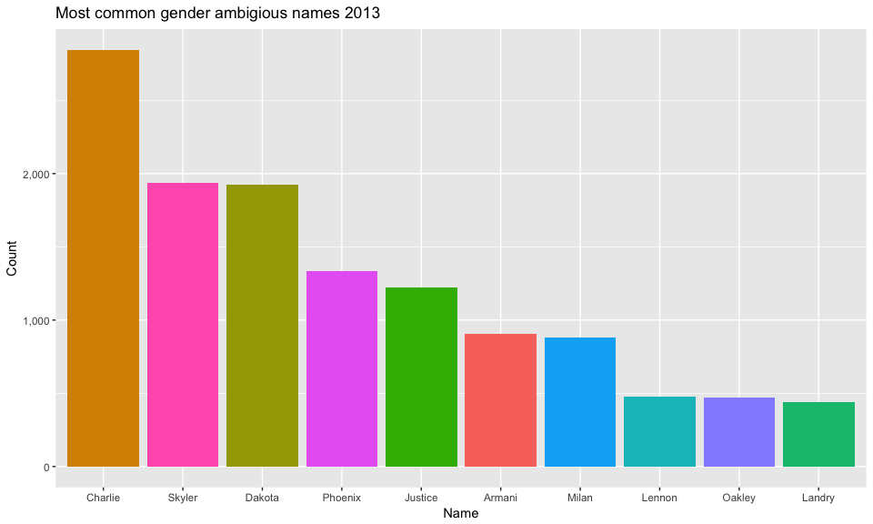

```r
# Most ambigious names for specific years
Gender_ambig_common_name(df = baby_names, yr = 2013)
```

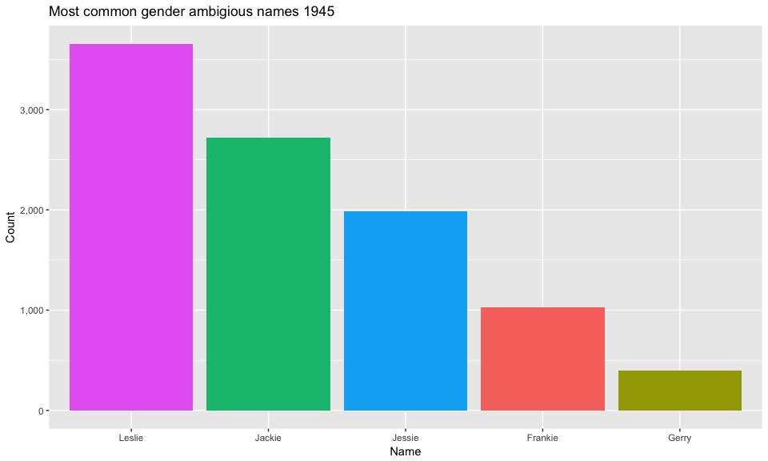

```r
Gender_ambig_common_name(df = baby_names, yr = 1945)
```

We can see that Jessie is the most common gender ambiguous name for all years, while in 2013 names such as Skyler and Armani are popular. The names from 1945 are more traditional compared to 2013.

### 2.4.2 Names that have exactly the same amount of male and females by year

This method finds the names that have the exact same amount of males and females. As mentioned earlier, this method tends to pick out unusual names with low counts. However, they are the **most ambigious names** with:

$$\sum Men = \sum Female$$

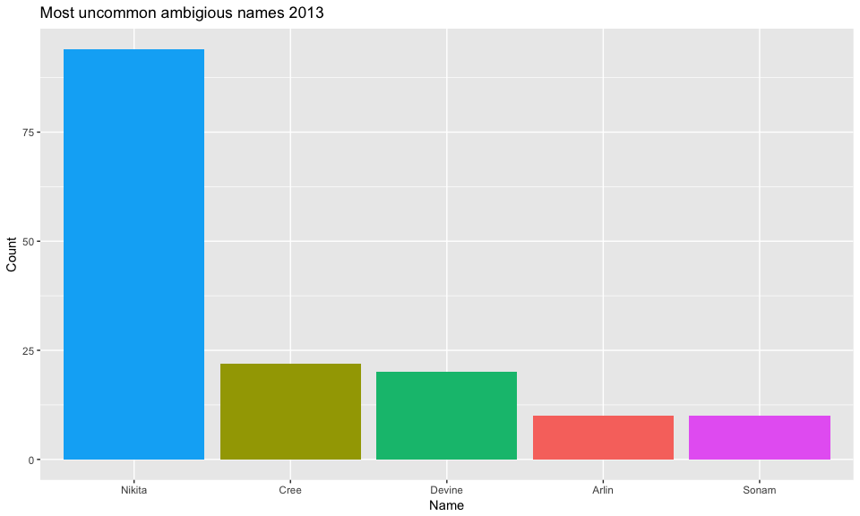

```r
Gender_ambig_name <- function(df, yr){

  # Filters for the year, aggregates to name, sex level and sums amount
  df <- df %>% filter(year == yr) %>% group_by(name, sex) %>%
    summarise(total = sum(amount)) %>% arrange(desc(total))

  # Keeps all duplicates, i.e. male and female of same name
  df <- df[duplicated(df$name) | duplicated(df$name, fromLast=TRUE), ]

  # Another dataframe that goes to name level,
  #therefore the difference between total is due to amount of male and female
  df_a <- df %>% group_by(name) %>% summarise(total_amt = sum(total)) %>%
    arrange(desc(total_amt)) %>% rename(total_male_female = total_amt)

  # Joins the 2 dataframes, allowing a ratio of male female to be calculated
  df <- left_join(df, df_a, by = "name")

  # Male/Female calculation ratio of total for each name
  df$ratio <- df$total / df$total_male_female

  # selects ratio of 0.5 and removes duplicates for clarity.
  # 0.5 corresponds to a name being exactly half male and half female
  df <- df %>% filter(ratio == 0.5) %>% distinct(name,.keep_all = T)

  # Visualising results
  ggplot(data = df, aes(x = reorder(name, -total_male_female), y = total_male_female, fill = name)) +
    geom_bar(stat = "identity") +
    scale_y_continuous(labels = comma) +
    guides(fill = FALSE) +
    ylab("Count") +
    xlab("Name") +
    ggtitle(label = paste("Most uncommon ambigious names", yr))

}

Gender_ambig_name(baby_names, yr = 2013)
```

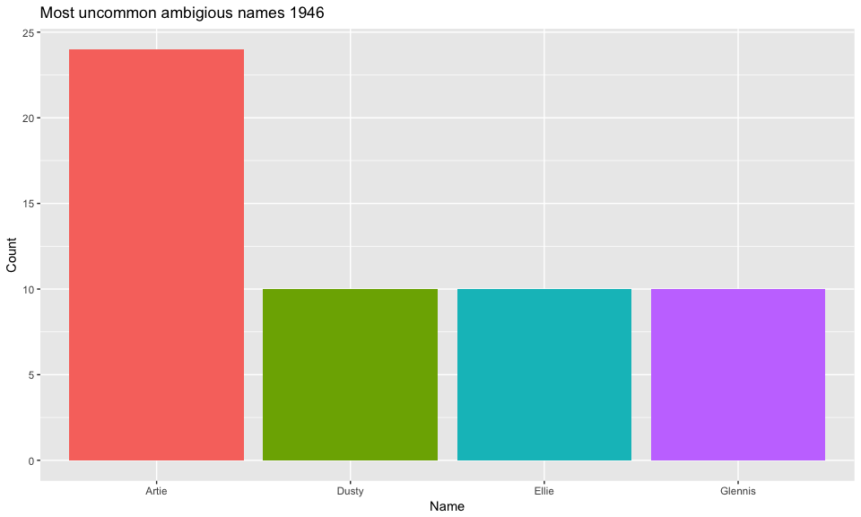

```r
Gender_ambig_name(baby_names, yr = 1946)
```

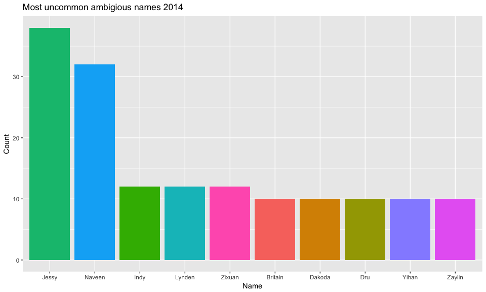

```r
Gender_ambig_name(baby_names, yr = 2014)
```

## 2.5 Names that have Increased and Decreased in Popularity with Time

One obvious thing to think about would be to examine names whose popularity have changed over time. This section picks out the biggest increase and decrease in popularity of names over a certain time period.

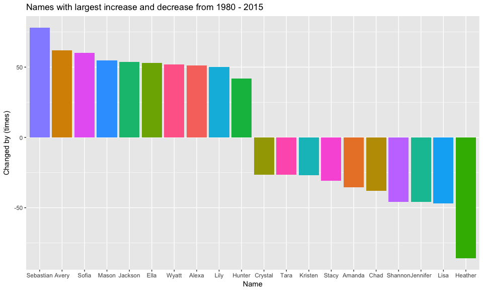

```r
change_popularity_time <- function(df, yr_1 = 1980, yr_2 = 2015){

  if(yr_1 < yr_2){
    a <- df %>% filter(year == yr_1) %>% group_by(name) %>%
      summarise(total = sum(amount))

    a <- a %>% mutate(pct_of_total_a = (total / sum(total)) * 100) %>%
      # select(name, pct_of_total_a) %>%
      arrange(desc(pct_of_total_a))

    b <- df %>% filter(year == yr_2) %>% group_by(name) %>%
      summarise(total = sum(amount))

    b <- b %>% mutate(pct_of_total_b = (total / sum(total)) * 100) %>%
      #select(name, pct_of_total_b) %>%
      arrange(desc(pct_of_total_b))

    c <- inner_join(a, b, by = "name")

    c <- filter(c, total.x >= 100 & total.y >= 100)

    c <- c %>% mutate(pct_change = ifelse(total.x < total.y, (total.y - total.x) / total.x,
                                          (total.y - total.x) / total.y)) %>%
      arrange(desc(pct_change))
    #%>% head(10)

    d <- c[1:10,]

    e <- c[(nrow(c) - 9): nrow(c),]

    f <- bind_rows(d,e)

    ggplot(data = f, aes(x = reorder(name, -pct_change), y = pct_change, fill = name)) +
      geom_bar(stat = "identity") +
      scale_y_continuous(labels = comma) +
      guides(fill = FALSE) +
      ylab("Changed by (times)") +
      xlab("Name") +
      ggtitle(label = paste("Names with largest increase and decrease from", yr_1, "-", yr_2))
  }else{
    print("yr_1 should be before yr_2, please swap their values")
  }
}

change_popularity_time(baby_names)
```

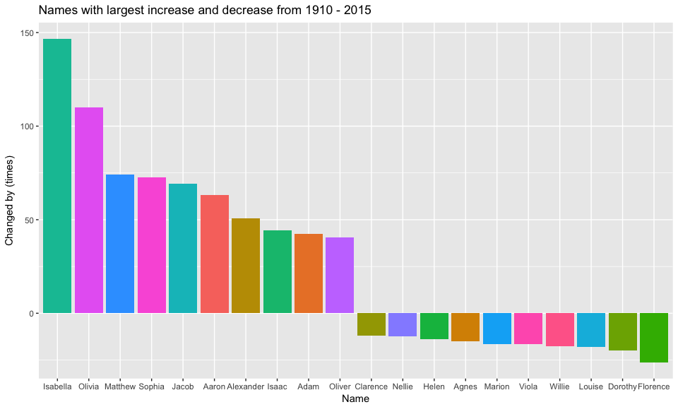

```r
change_popularity_time(baby_names, yr_1 = 1910, yr_2 = 2015)
```

## 2.6 Has Name Diversity Increased Over Time

One interesting idea was to examine if people are naming their children with more unique names over time.

### 2.6.1 Absolute Change

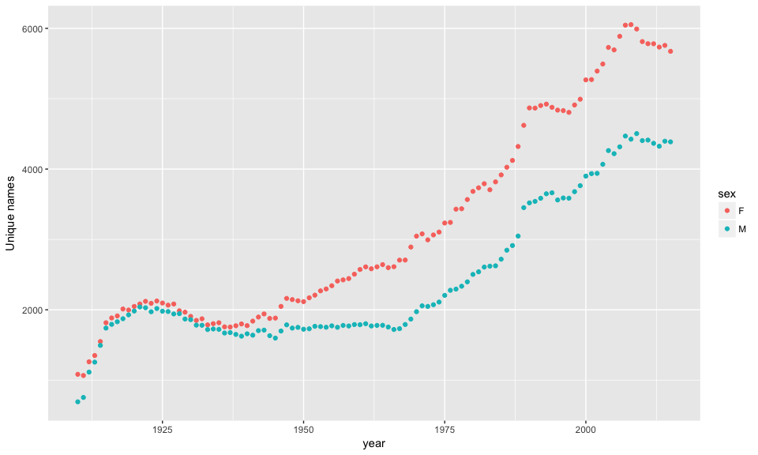

```r
name_diversity <- function(df){
  df <- df %>% group_by(year, sex) %>% summarise(total_unique = length(unique(name)))
  ggplot(data = df, aes(x = year, y = total_unique, color = sex)) +
    geom_point() +
    labs(y = "Unique names")
}
name_diversity(df = baby_names)
```

We can see that the number of unique names does increase over time for both males and females. However, as shown below, the number of births increases over time too, so this just could be a product of an increase in births. To check this, the next section normalises the unique names by total births that year.

### 2.6.2 Relative Change

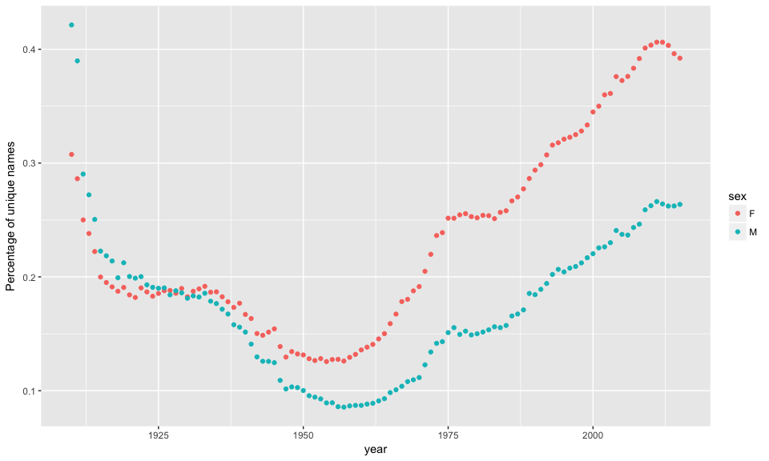

```r
name_diversity_normalised <- function(df){

  df <- df %>% group_by(year, sex) %>%
    summarise(total = sum(amount), total_unique = length(unique(name))) %>%
    mutate(unique_percentage = (total_unique / total) * 100)

  ggplot(data = df, aes(x = year, y = unique_percentage, color = sex)) +
    geom_point() +
    labs(y = "Percentage of unique names")
}

name_diversity_normalised(baby_names)
```

**One point to note**: The term uniqueness isn’t very accurate as a name must appear 5 times in a state in order to be part of this data set. So in reality, uniqueness is if a name only appears in one state that year. This is a limitation of the data and there isn’t much that can be done about it.

## 2.7 Birthrate as a Function of Time

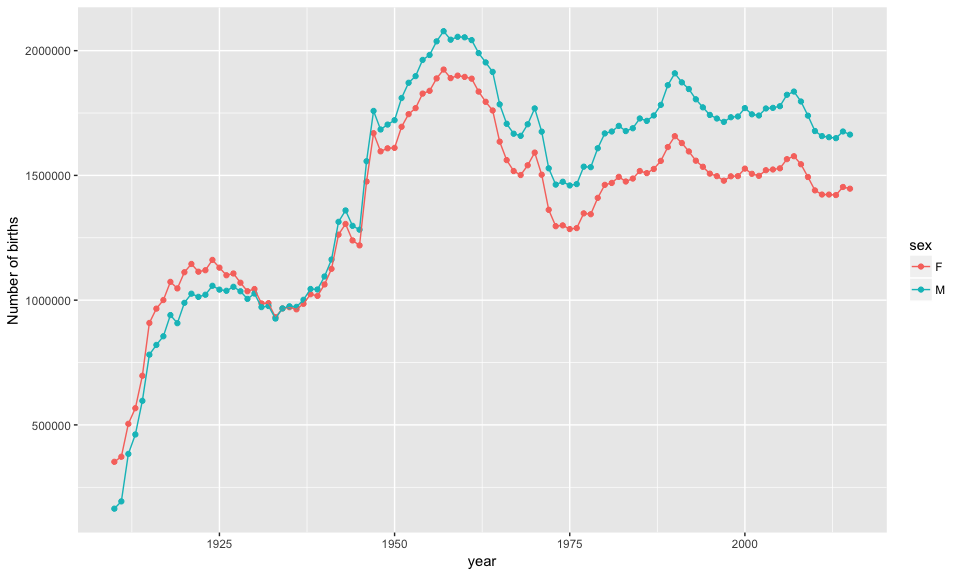

```r
birth_numbers_per_year <- function(df){
  df  <- df %>% group_by(year, sex) %>% summarise(total_births = sum(amount))
  ggplot(df, aes(x = year, y = total_births, color = sex)) + geom_point() + geom_line() + labs(y = "Number of births")
}

birth_numbers_per_year(baby_names)
```

| Year | Population |
| --- | --- |
| 1910 | 92,228,496 |
| 1930 | 123,202,624 |
| 1950 | 151,325,798 |
| 1970 | 203,211,926 |
| 1990 | 248,709,873 |
| 2010 | 308,745,538 |

## 2.8 Are Babies Named After Famous People

One might think that babies are named after famous names of the time.

```r
famous_name_check <- function(df, name_lookup = "Jackie"){
  df <- df %>% group_by(name, year) %>% summarise(total = sum(amount)) %>% filter(name == name_lookup)
  ggplot(data = df, aes(x = year, y = total, color = name_lookup)) +
    geom_point() + geom_line() + labs(y = "Number of names")
}
```

### 2.8.1 Jackie (Kennedy)

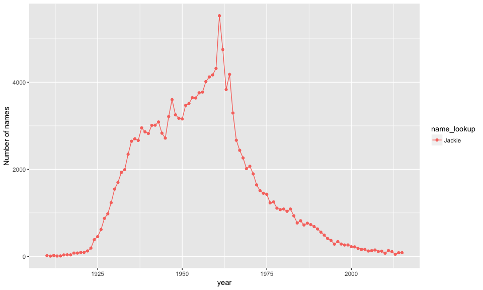

```r
famous_name_check(baby_names, name_lookup = "Jackie")
```

We see a peak of Jackie’s around 1960, this corresponds with the presidency of JFK.

### 2.8.2 Marilyn (Monroe)

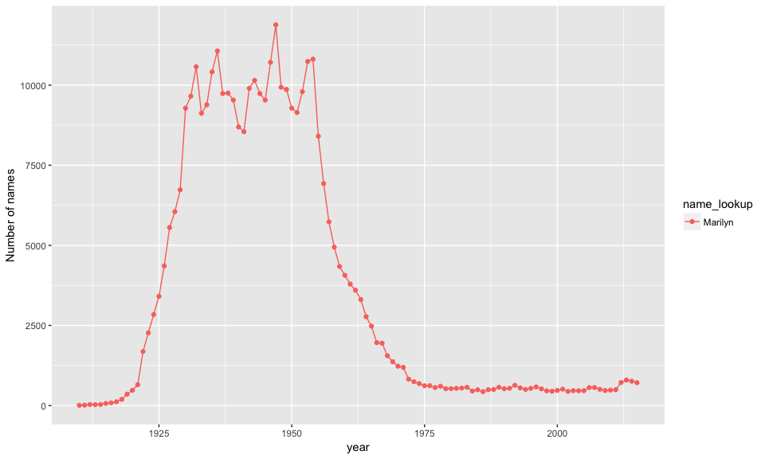

```r
famous_name_check(baby_names, name_lookup = "Marilyn")
```

### 2.8.3 Channing (Tatum)

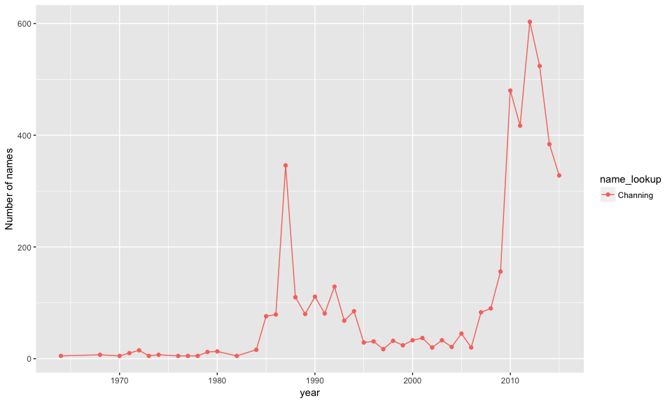

```r
famous_name_check(baby_names, name_lookup = "Channing")
```

We focus on a modern celebrity with a slightly unusual name in the form of Channing Tatum. There is a clear spike in the amount of Channings around 2010, this corresponds to when he became famous. There is another spike around the mid 80’s but I amn’t aware of any famous Channings from this time.